# HW3_Roser

## Question 1: What is the effect of cut quality on diamond price?

The effect of each cut on diamond price is as follows: From a Fair to Good cut diamond, the price decreases by an average of 429 dollars. From a Fair to a Very Good cut diamond, the price decreases by an average of 377 dollars. From a Fair to Ideal cut diamond, the price decreased by an average of 901 dollars. From a Fair to Premium cut diamond, the price increased by an average 225 dollars. You only care about the effect of cut on price of diamonds, the only cut worthwhile is premium. There’s a signficant difference in the effect of cut on diamond price because none of the confidence intervals cross zero.

```r
library(ggplot2)
library(ggplotgui)
#ggplot_shiny(diamond)

diamond<-read.csv("diamond.csv")

head(diamond)
```

```
##   price       cut carat
## 1   326     Ideal  0.23
## 2   326   Premium  0.21
## 3   327      Good  0.23
## 4   334   Premium  0.29
## 5   335      Good  0.31
## 6   336 Very Good  0.24
```

```r
str(diamond)
```

```
## 'data.frame':    53940 obs. of  3 variables:
##  $ price: int  326 326 327 334 335 336 336 337 337 338 ...
##  $ cut  : Factor w/ 5 levels "Fair","Good",..: 3 4 2 4 2 5 5 5 1 5 ...
##  $ carat: num  0.23 0.21 0.23 0.29 0.31 0.24 0.24 0.26 0.22 0.23 ...
```

```r
price_over_carat<-diamond$price/diamond$carat

gem_mod<-glm(price ~ cut, data = diamond, family = "poisson")
coef(gem_mod)
```

```
##  (Intercept)      cutGood     cutIdeal   cutPremium cutVery Good
##    8.3799424   -0.1038367   -0.2316292    0.0504411   -0.0904632
```

```r
exp(8.3799)  # $4358 is baseline for fair cut diamonds,
```

```
## [1] 4358.573
```

```r
exp(8.3799-0.1038)-exp(8.3799) #fair compared to good
```

```
## [1] -429.7311
```

```r
exp(8.3799-0.2316)-exp(8.3799) #fair compared to ideal
```

```
## [1] -901.0767
```

```r
exp(8.3799+0.0504)-exp(8.3799) #fair compared to premium
```

```
## [1] 225.302
```

```r
exp(8.3799-0.0906)-exp(8.3799) #fair compared to very good
```

```
## [1] -377.5266
```

```r
confint(gem_mod)  # all effects are significant
```

```
##                    2.5 %      97.5 %
## (Intercept)   8.37920242  8.38068216
## cutGood      -0.10470072 -0.10297248
## cutIdeal     -0.23240302 -0.23085517
## cutPremium    0.04966133  0.05122103
## cutVery Good -0.09125511 -0.08967112
```

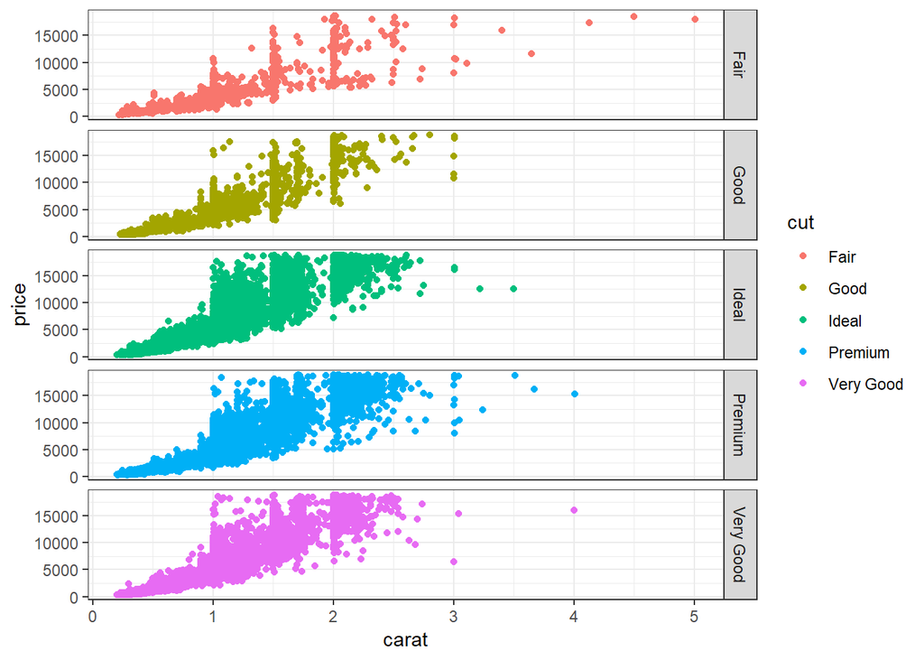

```r
scatter_diamond<- ggplot(diamond, aes(x = carat, y = price, colour = cut)) +
  geom_point() +
  facet_grid( cut ~ . ) +
  theme_bw()
scatter_diamond
```

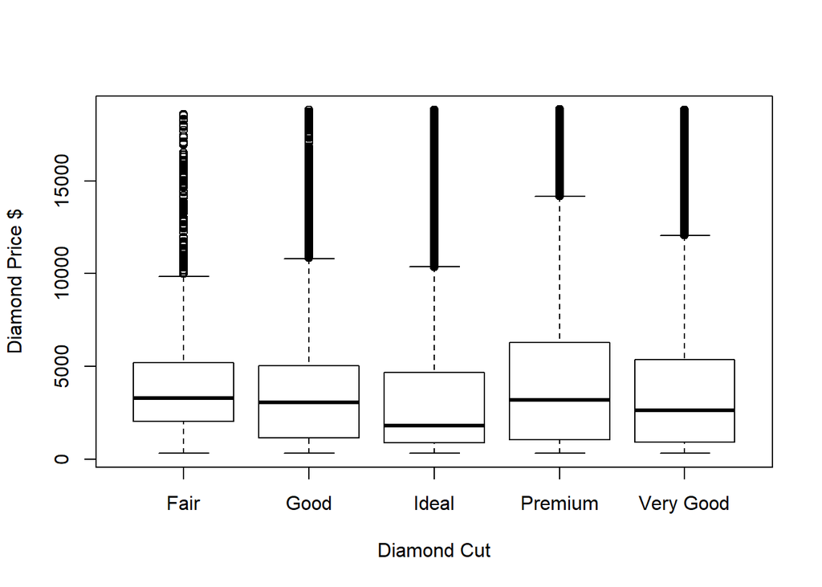

```r
boxplot(price~cut, data = diamond, xlab = "Diamond Cut", ylab = "Diamond Price $")
```

```r
#boxplot(price_over_carat~cut, data = diamond, xlab = "Diamond Cut", ylab = "Diamond Price$/Carat")
```

## Question 2: Does education have an impact on contraception use?

```r
cuse<-read.csv("contraception.csv")

head(cuse)
```

```
##     age education notUsing using Total
## 1   <25       low       53     6    59
## 2   <25       low       10     4    14
## 3   <25      high      212    52   264
## 4   <25      high       50    10    60
## 5 25-29       low       60    14    74
## 6 25-29       low       19    10    29
```

```r
str(cuse)
```

```
## 'data.frame':    16 obs. of  5 variables:
##  $ age      : Factor w/ 4 levels "<25","25-29",..: 1 1 1 1 2 2 2 2 3 3 ...
##  $ education: Factor w/ 2 levels "high","low": 2 2 1 1 2 2 1 1 2 2 ...
##  $ notUsing : int  53 10 212 50 60 19 155 65 112 77 ...
##  $ using    : int  6 4 52 10 14 10 54 27 33 80 ...
##  $ Total    : int  59 14 264 60 74 29 209 92 145 157 ...
```

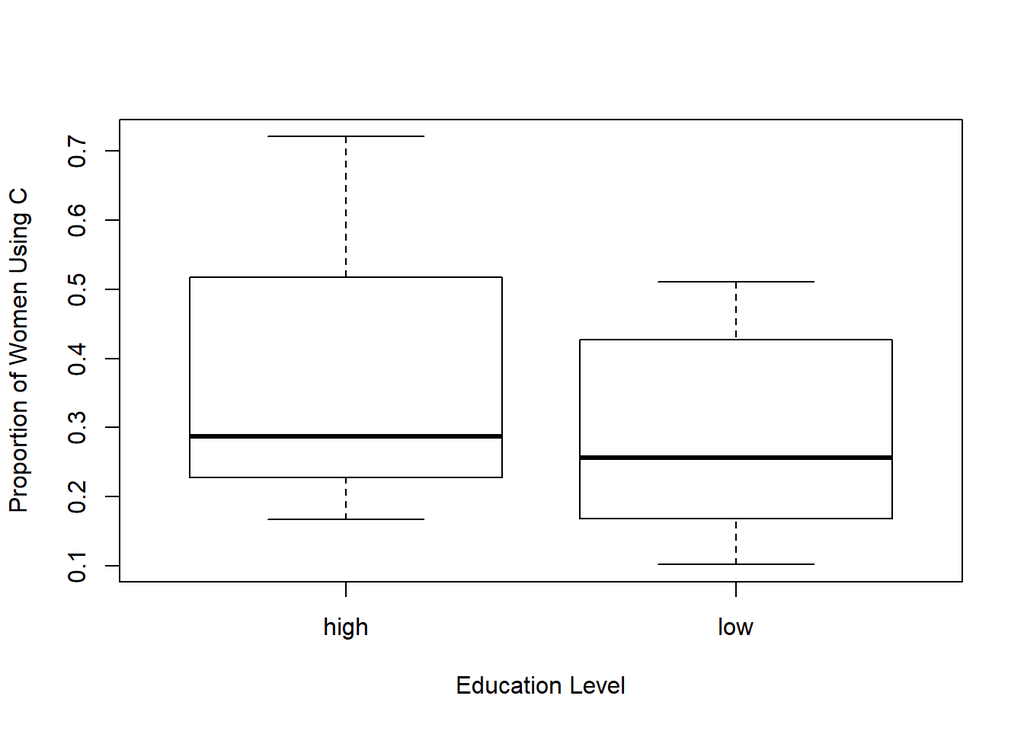

```r
prop_using<-cuse$using/cuse$Total
boxplot(prop_using~education, data = cuse, xlab = "Education Level", ylab = "Proportion of Women Using C")   #visualize data
```

```r
use_success<-cbind(cuse$using, cuse$notUsing)    #make response variable with both outcomes
use_mod<-glm(use_success~cuse$education, family = "binomial")

coef(use_mod)
```

```
##       (Intercept) cuse$educationlow
##       -0.81020374        0.09248529
```

```r
plogis(-0.8102 + 0.0924)-plogis(-0.8102)  #difference between total women who use contraception
```

```
## [1] 0.02002974
```

```r
confint(use_mod)
```

```
##                        2.5 %     97.5 %
## (Intercept)       -0.9460962 -0.6766394
## cuse$educationlow -0.1239481  0.3078275
```

## Question 3: Hurricanes and Himmicanes

Based on my analysis of the deadliness of hurricanes vs himmicanes, I observed that there are on average 9 more deaths in hurricanes with female names than in hurricanes with male names. The 95% CI interval does not cross zero, from which we can infer a significant effect of himmicanes vs hurricanes and their respective deadliness.

I’m unsure as to how Jung et al could have provided more confidence in their analyses because I ran the same data through a negative binomial which showed no significant effect on average deaths between himmicanes and hurricanes. I believe this is because the poisson distribution which was used first does not accurately represent the large variance of the hurricane dataset. The negative binomial distribution is a better fit from this data because the variance is much greater than the mean.

```r
library(MASS)
storm<-read.csv("Hurricane Dataset.csv")

head(storm)
```

```
##   Year     Name  MasFem MinPressure_before Minpressure_Updated.2014
## 1 1950     Easy 6.77778                958                      960
## 2 1950     King 1.38889                955                      955
## 3 1952     Able 3.83333                985                      985
## 4 1953  Barbara 9.83333                987                      987
## 5 1953 Florence 8.33333                985                      985
## 6 1954    Carol 8.11111                960                      960
##   Gender_MF Category alldeaths  NDAM Elapsed.Yrs Source  ZMasFem
## 1         F        3         2  1590          63    MWR -0.00094
## 2         M        3         4  5350          63    MWR -1.67076
## 3         M        1         3   150          61    MWR -0.91331
## 4         F        1         1    58          60    MWR  0.94587
## 5         F        1         0    15          60    MWR  0.48108
## 6         F        3        60 19321          59    MWR  0.41222
##   ZMinPressure_A    ZNDAM
## 1       -0.35636 -0.43913
## 2       -0.51125 -0.14843
## 3        1.03765 -0.55047
## 4        1.14091 -0.55758
## 5        1.03765 -0.56090
## 6       -0.25310  0.93174
```

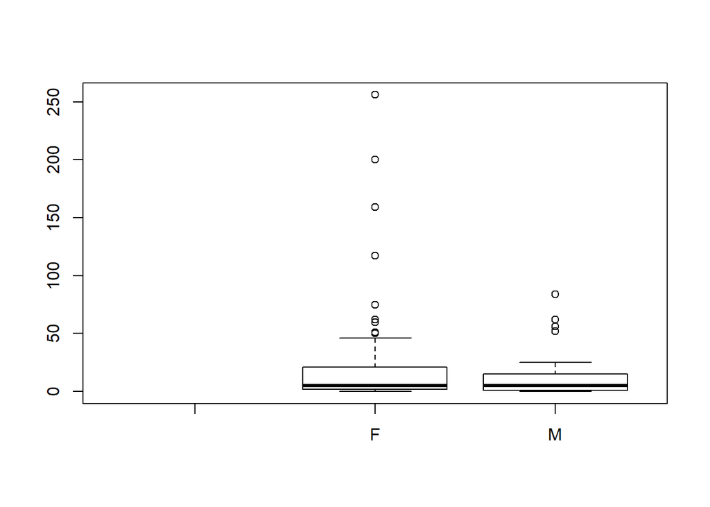

```r
boxplot(alldeaths~Gender_MF, data = storm)    #note extreme outlines in Female named hurricanes
```

```r
storm_mod<-glm(alldeaths~Gender_MF, data = storm, family = "poisson")
coef(storm_mod)
```

```
## (Intercept)  Gender_MFM
##   3.1679220  -0.5123354
```

```r
exp(3.167-0.5123)-exp(3.167)  #on average there's 9 more deaths in hurricanes than himmicanes
```

```
## [1] -9.51545
```

```r
confint(storm_mod)
```

```
##                  2.5 %     97.5 %
## (Intercept)  3.1164152  3.2185581
## Gender_MFM  -0.6211542 -0.4056501
```

```r
#testing with negative rbinom
storm_mod2<-glm.nb(alldeaths~Gender_MF, data = storm)
coef(storm_mod2)
```

```
## (Intercept)  Gender_MFM
##   3.1679220  -0.5123354
```

```r
confint(storm_mod2)  #shows the M/F is not significant effect on deaths--> poisson is nota good choice bc variance is not well represented for this data set.
```

```
##                 2.5 %    97.5 %
## (Intercept)  2.816448 3.5640722
## Gender_MFM  -1.149166 0.1720959
```

## Question 4: Dataset from Our Own Research: Shrub Counts

```r
shrub<-read.csv("shrub_edit.csv")
head(shrub)
```

```
##   Site Plot      Date Recorder Observer1 Observer2 Plot_100m Plot_10m
## 1 wbs1    1 31-May-16     cami    jordan      alex        ne       ne
## 2 wbs1    1 31-May-16     cami    jordan      alex        ne       ne
## 3 wbs1    1 31-May-16     cami    jordan      alex        ne       ne
## 4 wbs1    1 31-May-16     cami    jordan      alex        ne       sw
## 5 wbs1    1 31-May-16     cami    jordan      alex        nw       ne
## 6 wbs1    1 31-May-16     cami    jordan      alex        nw       ne
##   Species Count Density Location
## 1   arar8     6     0.6      WBS
## 2  artrw8     1     0.1      WBS
## 3   chvi8     3     0.3      WBS
## 4   arar8     1     0.1      WBS
## 5   arar8     7     0.7      WBS
## 6  artrw8     3     0.3      WBS
```

```r
str(shrub)
```

```
## 'data.frame':    355 obs. of  12 variables:
##  $ Site     : Factor w/ 9 levels "LOS1","LOS2",..: 7 7 7 7 7 7 7 7 7 7 ...
##  $ Plot     : int  1 1 1 1 1 1 1 1 1 1 ...
##  $ Date     : Factor w/ 17 levels "1-Jun-16","11-Jul-16",..: 15 15 15 15 15 15 15 15 15 15 ...
##  $ Recorder : Factor w/ 6 levels "alex","Alex",..: 4 4 4 4 4 4 4 4 4 4 ...
##  $ Observer1: Factor w/ 5 levels "Alex,Cami","cami",..: 4 4 4 4 4 4 4 4 4 4 ...
##  $ Observer2: Factor w/ 6 levels "","alex","Alex",..: 2 2 2 2 2 2 2 2 2 2 ...
##  $ Plot_100m: Factor w/ 4 levels "ne","nw","se",..: 1 1 1 1 2 2 2 2 2 2 ...
##  $ Plot_10m : Factor w/ 4 levels "ne","nw","se",..: 1 1 1 4 1 1 1 2 2 2 ...
##  $ Species  : Factor w/ 10 levels "arar","arar8",..: 2 4 5 2 2 4 10 2 4 10 ...
##  $ Count    : int  6 1 3 1 7 3 1 3 3 1 ...
##  $ Density  : num  0.6 0.1 0.3 0.1 0.7 0.3 0.1 0.3 0.3 0.1 ...
##  $ Location : Factor w/ 3 levels "LOS","MBS","WBS": 3 3 3 3 3 3 3 3 3 3 ...
```

```r
shrub_mod<-glm(Count~Location, data = shrub, family = "poisson")
coef(shrub_mod)
```

```
## (Intercept) LocationMBS LocationWBS
##   2.8873146  -0.7701327  -1.5061353
```

```r
exp(2.887-0.7701)-exp(2.887)   #comparison between LOS and MBS    On average there's 10 more shrubs in LOS plots than MBS plots
```

```
## [1] -9.63406
```

```r
exp(2.887-1.5063)-exp(2.887)   #comparison between LOS and WBS    On average there's 14 more shrubs in LOS plots than WBS plots
```

```
## [1] -13.96173
```

```r
exp(2.887-1.5063)-exp(2.887-0.7701) #comparison between WBS and MBS  On average there's 4 more shrubs in MBS plos than WBS plots
```

```
## [1] -4.327666
```

```r
confint(shrub_mod)  #Site location has a significant effect on the density of shrubs per 10m2
```

```
##                  2.5 %     97.5 %
## (Intercept)  2.8384172  2.9354265
## LocationMBS -0.8498115 -0.6909882
## LocationWBS -1.6012983 -1.4123797
```

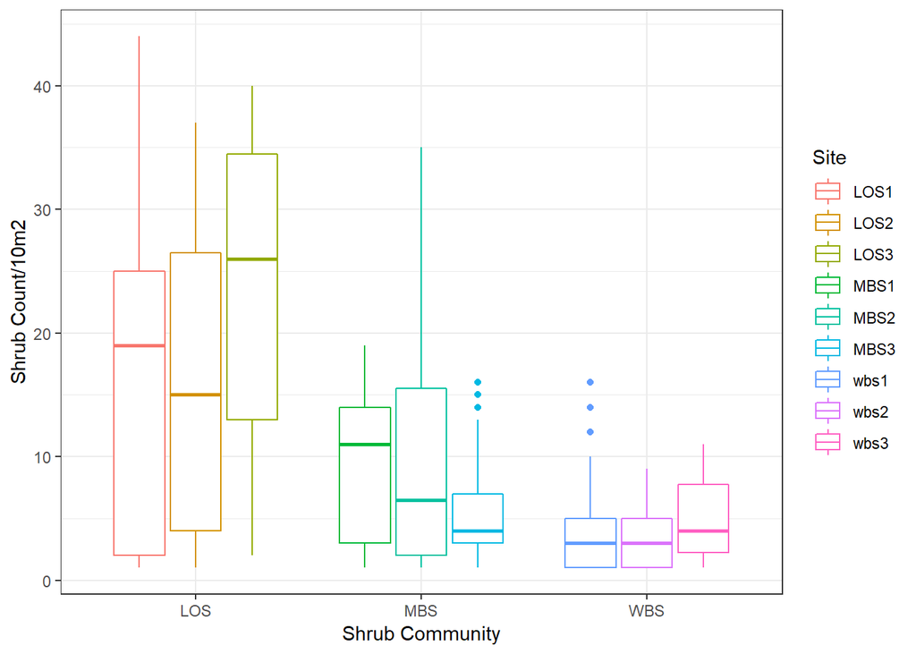

```r
#boxplot(Count~Location, data = shrub, xlab = "Shrub Community", ylab = "Shrub Count per 10m2")
shrub_graph <- ggplot(shrub, aes(x = Location, y = Count, colour = Site)) +
  geom_boxplot(notch = FALSE) +
  labs(x = 'Shrub Community', y = 'Shrub Count/10m2') +
  theme_bw()
shrub_graph
```